# Classification of Human Wrist Movement

Nicholas Favale (favale2), Wenzheng Hu (whu14), Doyeon Kim (dkim172), Zachary Quicksall (zsq2)

May 9, 2018

# Introduction

The goal of this investigation is to construct classification models capable of accurately detecting Activities of Daily Living (ADL). The modern society strongly emphasizes the importance of valuing one??s well-being. For example, Misfit, Fitbit, and other wearable fitness trackers are widely used to examine people??s fitness and health conditions. Companies like Spotify use classification algorithms to queue up songs based on users?? activity detected by phone movement, which will be different for running than for lifting weights. Other applications even include assistive rehabilitation devices that can assist the physically impaired in completing basic tasks such as brushing their teeth or sipping from a glass of water. The development of accurate and generalizable ADL recognition will establish a strong basis for improving the quality of human lives.

The data set, obtained from the UCI Machine Learning Repository, contains recordings of 14 ADL: `Brush Teeth`, `Climb Stairs`, `Comb Hair`, `Descend Stairs`, `Drink Glass`, `Eat Meat`, `Eat Soup`, `Get Up Bed`, `Lie down Bed`, `Pour Water`, `Sit Down Chair`, `Stand Up Chair`, `Use Telephone`, and `Walk`. Recordings of individuals performing each activity were gathered using wrist-worn triaxial accelerometers from 16 volunteers.

# Methods

### Preprocessing - Vector Quantization

Raw data were collected at 50 hertz by a single triaxial accelerometer attached to each volunteer??s right wrist. The ith observation of the raw data contains acceleration measured in the x, y, and z axes which correspond to the following directions of motion:

- x axis: pointing toward the hand (Vertical)
- y axis: pointing toward the left (Mediolateral)
- z axis: perpendicular to the plane of the hand (Anteroposterior)

Acceleration measurements, originally encoded in units of gravity (-1.5g to +1.5g), were mapped to integer values ranging from 0 to 63.

Due to the nature of different activities, the length of each recording can vary. As such, the data are unstructured and cannot be used directly for classification. To convert the data into a format useful for classification, vector quantization was used.

First, the raw data were segmented using a sliding window. Both window length $s$ and overlap $o$ were tuned using cross validation. Following segmentation, the two-dimensional signal was flattened into a vector and used as input for k-means clustering to group segments into $k$ clusters.

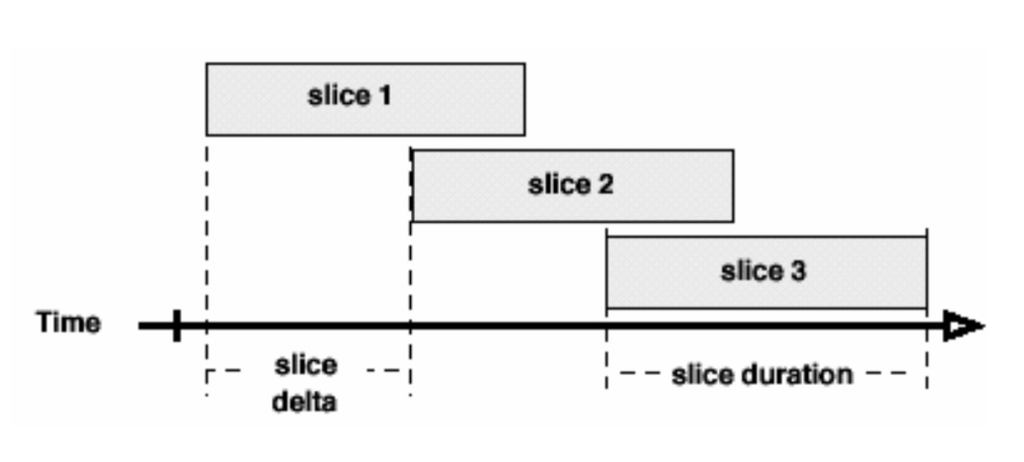

Then, for each activity example, the number of its segments belonging to each cluster are counted. The final feature vector for this observation is a vector $v$ with length $k$ where $v_i, (i = 1..k)$ represents the number of segments that belong to the ith cluster. This process was repeated for each activity example and the final data set was split 50/50 into train/test sets stratified by activity type.

### Predictive Modeling

Four types of statistical models were tuned in conjunction with preprocessing steps using 5-fold cross validation. The following table shows the chosen search space for each of the preprocessing parameters:

| Parameter | Symbol | Search Space |
| --- | --- | --- |
| Window Length | $s$ | 1, 5, 10, 20 |
| Window Overlap | $o$ | 0, 3, 5 |
| Number of Clusters | $k$ | 5, 10, 20 |

**Random Forest** Random forests were tuned across all possible values of mtry (mtry = 1..n, where n is the total number of features).

**Gradient Boosting Machine (GBM)** Initially, a coarse range of tuning parameters were selected and iteratively narrowed to create smaller tuning grids for the GBM model due to the linear and relatively slow rate of training compared to other tree-based models. The accuracy and ??Best Tune?? of each model iteration was recorded and used to update the grid. This process reduces training time.

**K-Nearest Neighbors (KNN)** Because KNN is a relatively simple and quick model compared to others used in this analysis, it was possible to test a wide range of parameters, or k-values, before testing. Specifically, parameters k between 3 and 100 (inclusive) were examined.

**Support Vector Machine (SVM)** Support vector machines using linear, polynomial, and gaussian kernels were trained across appropriate parameter search spaces using 5-fold cross validation. Optimal tuning parameters were selected on the basis of highest accuracy.

# Results

A summary of the testing and training accuracy of each model is presented below:

|  | Training Accuracy | Testing Accuracy |
| --- | --- | --- |
| Random Forest | 1.0000000 | 0.8455285 |
| Linear SVM | 0.9241147 | 0.8414634 |
| Polynomial SVM | 0.9898820 | 0.8048780 |
| Gaussian SVM | 1.0000000 | 0.7886179 |
| KNN | 0.8819562 | 0.7723577 |
| Gbm | 1.0000000 | 0.8292683 |

```
##           Reference
## Prediction  1  2  3  4  5  6  7  8  9 10 11 12 13 14
##         1   3  0  0  0  0  0  0  0  0  0  0  0  0  0
##         2   0 25  0  2  0  0  0  0  0  0  0  0  0  0
##         3   0  0  9  0  0  0  0  0  1  0  0  0  0  0
##         4   0  2  0 10  0  0  0  0  0  0  0  0  0  0
##         5   0  1  0  0 28  0  0  0  0  0  0  0  0  0
##         6   0  0  0  0  0  1  0  0  0  0  0  0  0  0
##         7   0  0  0  0  0  0  0  0  0  0  0  0  0  0
##         8   0  0  0  0  0  0  0 25  3  0  2  1  0  0
##         9   0  1  0  0  0  0  0  1  1  0  0  1  0  0
##         10  0  0  0  0  2  0  0  1  0 28  0  0  0  0
##         11  0  0  0  0  0  0  0  1  2  1 21  7  0  0
##         12  0  1  0  0  0  0  0  2  1  1  7 21  0  1
##         13  0  0  0  0  0  0  0  0  0  0  0  0  3  0
##         14  0  0  0  0  0  0  0  0  0  0  0  0  0 29
```

# Discussion

The aim of this paper is to develop a reliable activity recognition system using data from a wrist-worn accelerometer. While there are many publications detailing accurate models for activity classification–some which cover an even greater range of ADL than this current study–the majority of these investigations have been carried out using accelerometers mounted on the lower back or hip. While not inherently better than other locations, sensor placement at the wrist is advantageous in that many widely-adopted technologies such as smart watches and fitbits are already in use by the general population. Furthermore, these wrist-worn devices cause far less discomfort and would likely demonstrate greater adherence than sensors which must be attached to clothing near the back, hip, or other uncommon locations.

Given the importance of activity recognition, increases in either classification performance or diversity of activity types could provide substantial benefits to the community. Potential applications of this model beyond simple activity recognition could include monitoring of different physical activity levels which are tied to general health and aging. Alternatively, activity recognition technology could be adapted to intelligent assistive devices for individuals with disabilities. Admittedly, the sample size of this study likely does not capture the natural variation of the population which could lead to poor performance on an unseen population. Additional work in this area is necessary before developing truly universal and generalizable activity recognition systems.

# Appendix B

| Activity Class (Number) | Activity Type |
| --- | --- |
| 1 | Brush teeth |
| 2 | Climb stairs |
| 3 | Comb hair |
| 4 | Descend stairs |
| 5 | Drink glass |
| 6 | Eat meat |
| 7 | Eat soup |
| 8 | Getup bed |
| 9 | Liedown bed |
| 10 | Pour water |
| 11 | Sitdown chair |
| 12 | Standup chair |
| 13 | Use telephon |
| 14 | Walk |